# quiz2_review

```python
from datascience import *
import numpy as np

%matplotlib inline
import matplotlib.pyplot as plots
plots.style.use('fivethirtyeight')
```

## Choosing and Creating Visualizations

For each scenario below,

- choose the most appropriate visualization,
- justify your choice
- create the visualization

### Scenario 1

In the census table below, visualize the way the 2010 base estimate changes as age increases.

```python
census2010 = Table.read_table('nc-est2019-agesex-res.csv').where('SEX', 0).where('AGE', are.below(999)).select('AGE', 'ESTIMATESBASE2010')
census2010.show(3)
```

| AGE | ESTIMATESBASE2010 |
| --- | --- |
| 0 | 3944160 |
| 1 | 3978090 |
| 2 | 4096939 |

... (98 rows omitted)

### Solution 1

A line plot is most appropriate since we have numerical input (age) and the output (2010 estimate) is a function of the input. (That is, each input specifies a single output.)

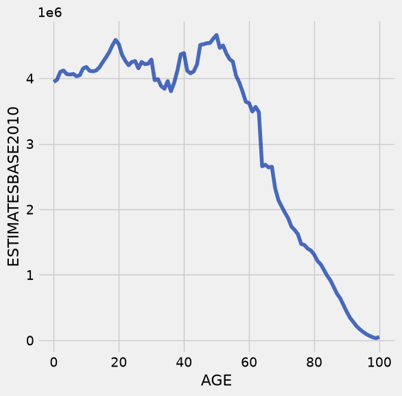

```python
census2010.plot('AGE', 'ESTIMATESBASE2010')
```

### Scenario 2

In the film table below, visualize the correlation (if any) between year of release and rating.

```python
movies = Table.read_table('imdb.csv')
movies.show(3)
```

| Votes | Rating | Title | Year | Decade |
| --- | --- | --- | --- | --- |
| 88355 | 8.4 | M | 1931 | 1930 |
| 132823 | 8.3 | Singin' in the Rain | 1952 | 1950 |
| 74178 | 8.3 | All About Eve | 1950 | 1950 |

... (247 rows omitted)

### Solution 2

A scatter plot is most appropriate since we have numerical input (year) and numerical output (rating), but the output is not a function of the input. That is, each year will have many ratings associated with it (one for each movie released that year).

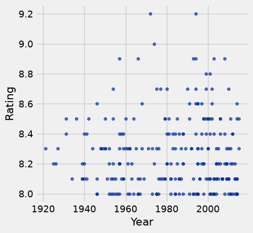

```python
movies.scatter('Year', 'Rating')
```

### Scenario 3

In the film table below, visualize the number of movies released by each studio.

```python
movies2 = Table.read_table('top_movies_2017.csv')
movies2.show(3)
```

| Title | Studio | Gross | Gross (Adjusted) | Year |
| --- | --- | --- | --- | --- |
| Gone with the Wind | MGM | 198676459 | 1796176700 | 1939 |
| Star Wars | Fox | 460998007 | 1583483200 | 1977 |
| The Sound of Music | Fox | 158671368 | 1266072700 | 1965 |

... (197 rows omitted)

### Solution 3

A bar chart is most appropriate since we have a categorical input (studio) and want to count the frequency with which each appears in the table.

| Studio | count |
| --- | --- |
| AVCO | 1 |
| Buena Vista | 35 |
| Columbia | 9 |

... (20 rows omitted)

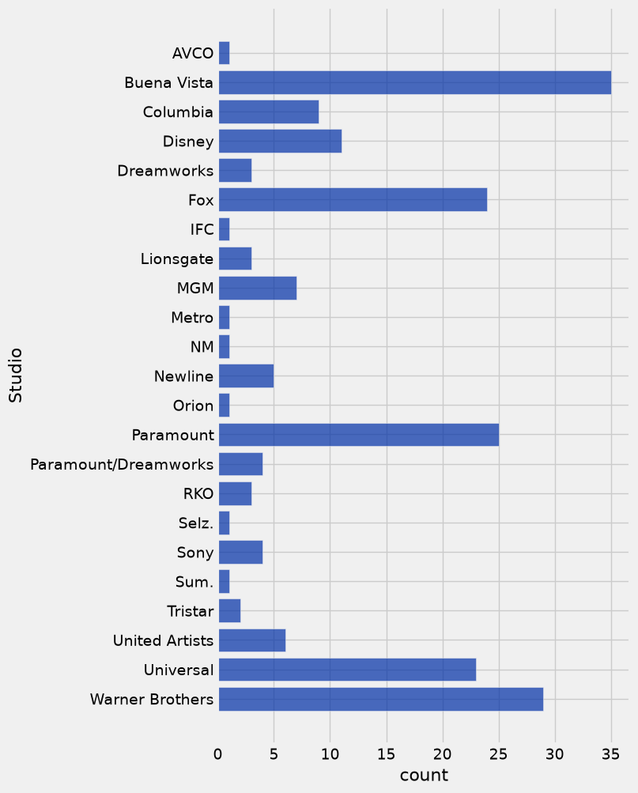

```python
studio_counts = movies2.group('Studio') # must group first to get the frequencies
studio_counts.show(3)

studio_counts.barh('Studio') # plot is generated using the counts table
```

### Scenario 4

In the films table below, visualize the distribution of the votes cast.

```python
movies = Table.read_table('imdb.csv')
movies.show(3)
```

| Votes | Rating | Title | Year | Decade |
| --- | --- | --- | --- | --- |
| 88355 | 8.4 | M | 1931 | 1930 |
| 132823 | 8.3 | Singin' in the Rain | 1952 | 1950 |
| 74178 | 8.3 | All About Eve | 1950 | 1950 |

... (247 rows omitted)

### Solution 4

A histogram is most appropriate since we have a numerical statistic for each movie and we want to visualize it's distribtion (that is, how the number of votes cast is spread out).

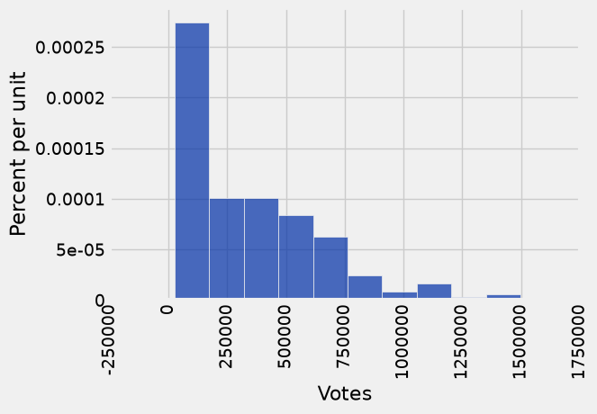

```python
movies.hist('Votes', bins = 10) # creates 10 equal-sized bins
```

## Interpreting Histograms

In the histogram below, what *percent* of the data falls between 0 and 10? (Be able to show your calculation based on the histogram, not on the array.)

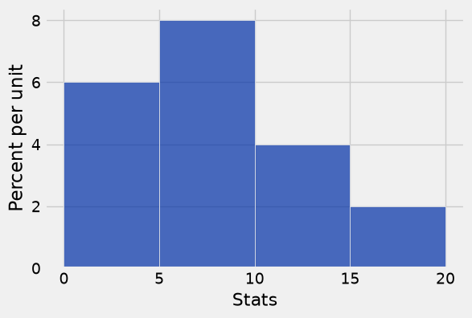

```python
stats = make_array(1, 2, 3, 5, 6, 8, 8, 10, 14, 19)
stats_table = Table().with_column('Stats', stats)
stats_table.hist('Stats', bins = np.arange(0, 21, 5))
```

### Solution

We want to calculate the area represented by the first two bars, which is show in the code cell below.

```python
5 * 6 + 5 * 8  # height x width of first bar plus height x width of second bar
```

```
70
```